# Lab6

Lili Xu

10/1/2021

## Download the Dataset

```r
library(tidyverse)
```

```r
library(tibble)
library(dplyr)
library(ggplot2)
library(tidytext)
```

```r
if (!file.exists("mtsamples.csv"))
  download.file(
    url = "https://raw.githubusercontent.com/USCbiostats/data-science-data/master/00_mtsamples/mtsamples.csv",
    destfile = "mtsamples.csv",
    method = "libcurl",
    timeout = 60
  )
mtsamples <- read.csv("mtsamples.csv")
mtsamples <- as_tibble(mtsamples)
mtsamples
```

```
## # A tibble: 4,999 x 6
##        X description    medical_special… sample_name  transcription   keywords
##    <int> <chr>          <chr>            <chr>        <chr>           <chr>
##  1     0 " A 23-year-o… " Allergy / Imm… " Allergic … "SUBJECTIVE:, … "allergy …
##  2     1 " Consult for… " Bariatrics"    " Laparosco… "PAST MEDICAL … "bariatri…
##  3     2 " Consult for… " Bariatrics"    " Laparosco… "HISTORY OF PR… "bariatri…
##  4     3 " 2-D M-Mode.… " Cardiovascula… " 2-D Echoc… "2-D M-MODE: ,… "cardiova…
##  5     4 " 2-D Echocar… " Cardiovascula… " 2-D Echoc… "1.  The left … "cardiova…
##  6     5 " Morbid obes… " Bariatrics"    " Laparosco… "PREOPERATIVE … "bariatri…
##  7     6 " Liposuction… " Bariatrics"    " Liposucti… "PREOPERATIVE … "bariatri…
##  8     7 " 2-D Echocar… " Cardiovascula… " 2-D Echoc… "2-D ECHOCARDI… "cardiova…
##  9     8 " Suction-ass… " Bariatrics"    " Lipectomy… "PREOPERATIVE … "bariatri…
## 10     9 " Echocardiog… " Cardiovascula… " 2-D Echoc… "DESCRIPTION:,… "cardiova…
## # … with 4,989 more rows
```

## Question 1: What specialties do we have?

We can use count() from dplyr to figure out how many different catagories do we have? Are these catagories related? overlapping? evenly distributed?

```r
specialties <- mtsamples %>%
  count(medical_specialty)

specialties %>%
  arrange(desc(n))%>%
  top_n(15) %>%
  knitr::kable()
```

| medical_specialty | n |
| --- | --- |
| Surgery | 1103 |
| Consult - History and Phy. | 516 |
| Cardiovascular / Pulmonary | 372 |
| Orthopedic | 355 |
| Radiology | 273 |
| General Medicine | 259 |
| Gastroenterology | 230 |
| Neurology | 223 |
| SOAP / Chart / Progress Notes | 166 |
| Obstetrics / Gynecology | 160 |
| Urology | 158 |
| Discharge Summary | 108 |
| ENT - Otolaryngology | 98 |
| Neurosurgery | 94 |
| Hematology - Oncology | 90 |

There are 40 specialties. Let’s take a look at the distribution.

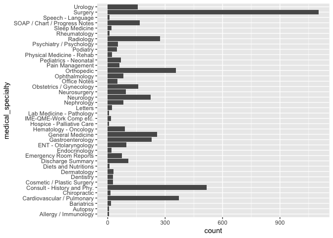

```r
ggplot(mtsamples, aes(x = medical_specialty)) +
  geom_histogram(stat = "count") +
  coord_flip()
```

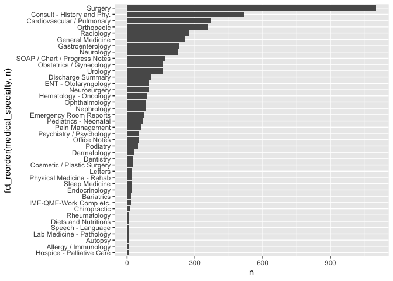

```r
# method 2
ggplot(specialties, aes(x = n, y = fct_reorder(medical_specialty, n))) +
  geom_col()
```

There are not evenly (uniformly) distribution. There is no overlapping happen.

## Question 2

Explain what we see from this result. Does it makes sense? What insights (if any) do we get?

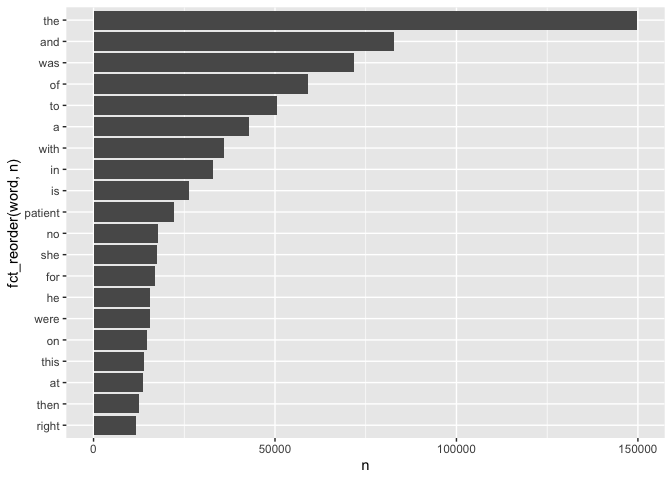

```r
mtsamples %>%
  unnest_tokens(output = word, input = transcription) %>%
  count(word, sort = TRUE) %>%
  top_n(20) %>%
  ggplot(aes(x=n, y = fct_reorder(word,n))) +
    geom_col()
```

The word “patient” seems to be important, but we observe a lot of stop words.

## Question 3

Redo visualization but remove stopwords before What do we see know that we have removed stop words? Does it give us a better idea of what the text is about?

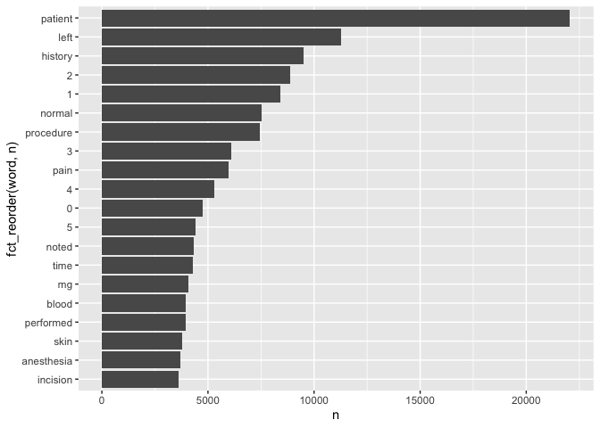

```r
mtsamples %>%
  unnest_tokens(output = word, input = transcription) %>%
  count(word, sort = TRUE) %>%
  anti_join(stop_words, by = c("word")) %>%
  top_n(20) %>%
  ggplot(aes(x=n, y = fct_reorder(word,n))) +
    geom_col()
```

Looking better , but we don’t like the numbers.

Bonus points if you remove numbers as well

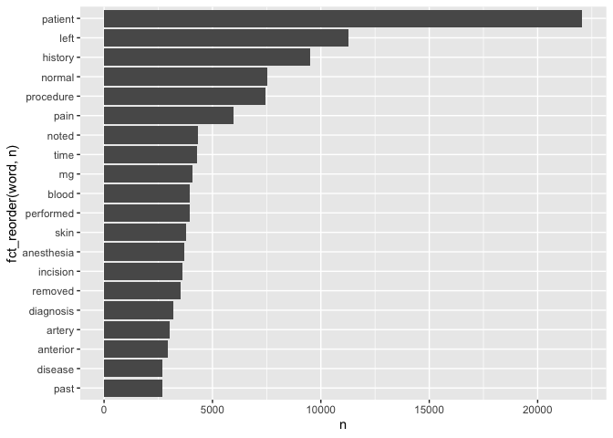

```r
# method 1
tokens_clean <- mtsamples %>%
  unnest_tokens(output = word, input = transcription) %>%
  count(word, sort = TRUE) %>%
  anti_join(stop_words, by = c("word"))

nums <- tokens_clean %>% filter(str_detect(word, "^[0-9]")) %>% select(word) %>% unique()

tokens_clean %>%
  anti_join(nums, by = c("word")) %>%
  top_n(20) %>%
  ggplot(aes(x=n, y = fct_reorder(word,n))) +
    geom_col()
```

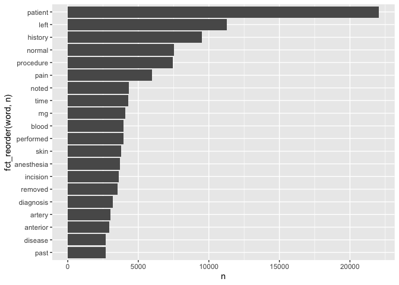

```r
# method 2
mtsamples %>%
  unnest_tokens(output = word, input = transcription) %>%
  count(word, sort = TRUE) %>%
  anti_join(stop_words, by = c("word")) %>%
  # using regular expressions to remove numbers
  filter(!grepl(pattern = "^[0-9]+$", x = word)) %>%
  top_n(20) %>%
  ggplot(aes(x=n, y = fct_reorder(word,n))) +
    geom_col()
```

Without the spotwords and number, we can see more relative words in the dataset.

## Question 4

repeat question 2, but this time tokenize into bi-grams. how does the result change if you look at tri-grams?

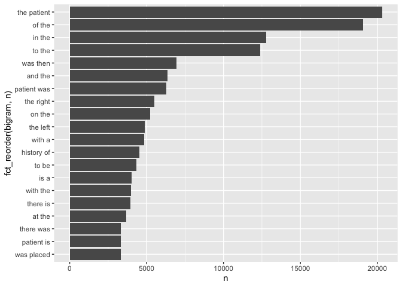

```r
mtsamples %>%
  unnest_ngrams(output = bigram, input = transcription, n = 2) %>%
  count(bigram, sort = TRUE) %>%
  top_n(20) %>%
  ggplot(aes(x=n, y = fct_reorder(bigram,n))) +
    geom_col()
```

Using bi-grams is not very informative, Let’s try trigrams:

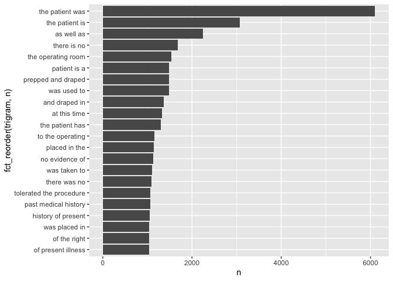

```r
mtsamples %>%
  unnest_ngrams(output = trigram, input = transcription, n = 3) %>%
  count(trigram, sort = TRUE) %>%
  top_n(20) %>%
  ggplot(aes(x=n, y = fct_reorder(trigram,n))) +
    geom_col()
```

Now some phrase start to show up, e.g., “tolerated the procedure”, “prepped and draped”.

## Question 5

Using the results you got from questions 4. Pick a word and count the words that appears after and before it.

Pick the word: Patient

```r
bigrams <- mtsamples %>%
  unnest_ngrams(output = bigram, input = transcription, n = 2) %>%
  separate(bigram, into = c("w1", "w2"), sep = " ") %>%
  filter((w1 == "patient") | (w2 == "patient"))
bigrams %>%
  filter(w1 == "patient") %>%
  select(w1, w2) %>%
  count(w2, sort = TRUE)
```

```
## # A tibble: 588 x 2
##    w2            n
##    <chr>     <int>
##  1 was        6293
##  2 is         3332
##  3 has        1417
##  4 tolerated   994
##  5 had         888
##  6 will        616
##  7 denies      552
##  8 and         377
##  9 states      363
## 10 does        334
## # … with 578 more rows
```

```r
bigrams %>%
  filter(w2 == "patient") %>%
  select(w1, w2) %>%
  count(w1, sort = TRUE)
```

```
## # A tibble: 269 x 2
##    w1            n
##    <chr>     <int>
##  1 the       20307
##  2 this        470
##  3 history     101
##  4 a            67
##  5 and          47
##  6 procedure    32
##  7 female       26
##  8 with         25
##  9 use          24
## 10 old          23
## # … with 259 more rows
```

Since we are looking at single words again, it is a good idea to treat these as single tokens. So let’s remove the stopwords and the numbers

```r
bigrams %>%
  filter(w1 == "patient") %>%
  filter(!(w2 %in% stop_words$word) & !grepl("^[0-9]+$", w2)) %>%
  count(w2, sort = TRUE) %>%
  top_n(10) %>%
  knitr::kable(caption = "Words AFTER 'patient'")
```

Words AFTER ‘patient’

| w2 | n |
| --- | --- |
| tolerated | 994 |
| denies | 552 |
| underwent | 180 |
| received | 160 |
| reports | 155 |
| understood | 113 |
| lives | 81 |
| admits | 69 |
| appears | 68 |
| including | 67 |

```r
bigrams %>%
  filter(w2 == "patient") %>%
  filter(!(w1 %in% stop_words$word) & !grepl("^[0-9]+$", w1)) %>%
  count(w1, sort = TRUE) %>%
  top_n(10) %>%
  knitr::kable(caption = "Words BEFORE 'patient'")
```

Words BEFORE ‘patient’

| w1 | n |
| --- | --- |
| history | 101 |
| procedure | 32 |
| female | 26 |
| sample | 23 |
| male | 22 |
| illness | 16 |
| plan | 16 |
| indications | 15 |
| allergies | 14 |
| correct | 11 |
| detail | 11 |

## Question 6

Which words are most used in each of the specialties. you can use group_by() and top_n() from dplyr to have the calculations be done within each specialty. Remember to remove stopwords. How about the most 5 used words?

```r
mtsamples %>%
  unnest_tokens(output = word, input = transcription) %>%
  group_by(medical_specialty) %>%
  count(word, sort = TRUE) %>%
  filter(!(word %in% stop_words$word) & !grepl("^[0-9]+$", word)) %>%
  top_n(5) %>%
  arrange(medical_specialty, desc(n)) %>%
  knitr::kable()
```

| medical_specialty | word | n |
| --- | --- | --- |
| Allergy / Immunology | history | 38 |
| Allergy / Immunology | noted | 23 |
| Allergy / Immunology | patient | 22 |
| Allergy / Immunology | allergies | 21 |
| Allergy / Immunology | nasal | 13 |
| Allergy / Immunology | past | 13 |
| Autopsy | left | 83 |
| Autopsy | inch | 59 |
| Autopsy | neck | 55 |
| Autopsy | anterior | 47 |
| Autopsy | body | 40 |
| Bariatrics | patient | 62 |
| Bariatrics | history | 50 |
| Bariatrics | weight | 36 |
| Bariatrics | surgery | 34 |
| Bariatrics | gastric | 30 |
| Cardiovascular / Pulmonary | left | 1550 |
| Cardiovascular / Pulmonary | patient | 1516 |
| Cardiovascular / Pulmonary | artery | 1085 |
| Cardiovascular / Pulmonary | coronary | 681 |
| Cardiovascular / Pulmonary | history | 654 |
| Chiropractic | pain | 187 |
| Chiropractic | patient | 85 |
| Chiropractic | dr | 66 |
| Chiropractic | history | 56 |
| Chiropractic | left | 54 |
| Consult - History and Phy. | patient | 3046 |
| Consult - History and Phy. | history | 2820 |
| Consult - History and Phy. | normal | 1368 |
| Consult - History and Phy. | pain | 1153 |

[output cut: 180 more lines]

The table shown above is top 5 word per medical specialty. But if there exist ties, like Allergy / Immunology, which contains different words but same times, it also will show up.

## Question 7

Find your own insight in the data: